# Homework 5

Kyle Landolt

March 30, 2015

For this assigment you will use a dataset of housing prices in Boston. These data were used in an early publication in environmental economics to study the effect of air quality on housing price. You can get a copy of the data in the spdep R package. Don’t forget to use `install.packages` if you need to!

```r
library(spdep)
data(boston)
```

Most of these variables were selected because Economic theory suggests that each should impact median value. A scatterplot matrix is a helpful to quickly visualize many bivariate relations. I like the scatterpot matrix function in the GGally package called `ggpairs`. Sorry it looks so bad printed out. It’s better on a big screen.

```r
library(ggplot2)
library(GGally)
library(dplyr)
```

Descriptions of the variables are: - **AGE** a numeric vector of proportions of owner-occupied units built prior to 1940 - **RM** a numeric vector of average numbers of rooms per dwelling - **logDIS** log(a numeric vector of weighted distances to five Boston employment centres) - **B** a numeric vector of 1000*(Bk - 0.63)^2 where Bk is the proportion of blacks - **LSTAT** a numeric vector of percentage values of lower status population - **PRATIO** a numeric vector of pupil-teacher ratios per town (constant for all Boston tracts) - **NOX** a numeric vector of nitric oxides concentration (parts per 10 million) per town - **logMEDV** log(a numeric vector of median values of owner-occupied housing in USD 1000)

We are trying to understand the various determinants of house price, including air pollution. One of the most important aspects of house price in the US is suburbanization. From the scatterplots, we see a significant relationship between value and distance. It may be helpful to map this out. You could use Latitude and Longitude to map it out, but it is better to use projected coordinates, which are in units of meters, rather than in units of geographic degrees. Fortunately, these have already been calculated for you.  
(Note, a GIS course would teach you more about projections.  
You could do the projection using GIS software like Quantum GIS or ArcGIS, or you could do it in R using the spTransform function in the sp package.)

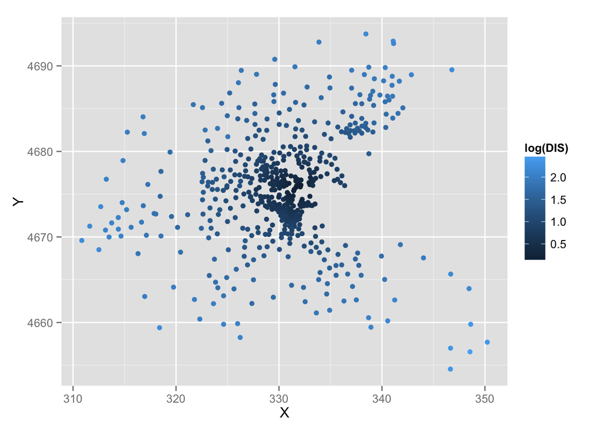

```r
boston.c$X <- boston.utm[,1]
boston.c$Y <- boston.utm[,2]
ggplot(boston.c) + geom_point(aes(x=X, y=Y, color=log(DIS)))
```